# Cmsc320 Final Project Data Pipeline Tutorial

Christopher Yang

May 22, 2019

# **Question:**

**Which risk factors are correlated with heart disease the most (for patients who are admitted to the clinic with high risk factors for heart disease)? And how accurately can these risk factors predict whether an patient has heart disease or not?** Using a dataset of individuals with chest pain who are admitted to the doctors office with high risk factors, we will attempt to perform analysis on this topic and walk users through the entire data science pipeline. (Data curation, parsing, management; Exploratory data analysis; Hypothesis testing; Machine learning to provide analysis; and finally, insight gained on this analysis).

The goal will be to find out how accurately we can determine if an individual (who is admitted to the clinic and has the appropriate risk criteria) has heart disease. This will be done in the machine learning step, where random forest will be used to find the most significant risk factors.

# **Finding a dataset to use:**

To start this R tutorial, we will be using the dataset for heart disease from Kaggle datasets. The link to this dataset is shown below:

https://www.kaggle.com/ronitf/heart-disease-uci

Download, and extract the zip file. The file name is heart.csv

# **Data ingestion:**

**information on read_csv function**

http://rprogramming.net/read-csv-in-r/

https://www.datacamp.com/community/tutorials/r-tutorial-read-excel-into-r

https://swcarpentry.github.io/r-novice-inflammation/11-supp-read-write-csv/

**information on tidyverse**

https://rstudio-education.github.io/tidyverse-cookbook/program.html

The first step in the Data Pipeline is to load the dataset into R. This is the data ingestion step. To load the dataset, we will use the read_csv function.

Note that this function is part of the tidyverse package, and to use it we will need to have the tidyverse package installed. (Installing a package is very easy, just go to Packages, then click Install, and type out the name of the package, which is tidyverse). This tutorial will use other libraries as well, so you can use this step to load other libraries as you go along if they are not already installed.

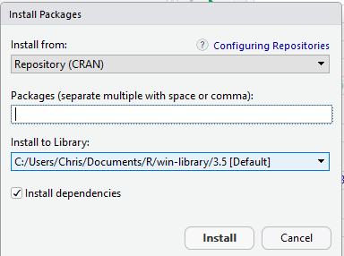

Alternatively, you can use this:

**install.packages(“tidyverse”)**

Run the code below, to load the tidyverse package:

```r
library(tidyverse)
```

Once the respective packages are loaded you can use the following code below to ingest the data from a CSV file:

**Make sure the filepath is correct, or you may encounter an error!**

```r
data <- read.csv(file="C:/Users/Chris/Documents/heart.csv", header=TRUE, sep=",", fileEncoding="UTF-8-BOM")

head(data)
```

```
##   age sex cp trestbps chol fbs restecg thalach exang oldpeak slope ca thal
## 1  63   1  3      145  233   1       0     150     0     2.3     0  0    1
## 2  37   1  2      130  250   0       1     187     0     3.5     0  0    2
## 3  41   0  1      130  204   0       0     172     0     1.4     2  0    2
## 4  56   1  1      120  236   0       1     178     0     0.8     2  0    2
## 5  57   0  0      120  354   0       1     163     1     0.6     2  0    2
## 6  57   1  0      140  192   0       1     148     0     0.4     1  0    1
##   target
## 1      1
## 2      1
## 3      1
## 4      1
## 5      1
## 6      1
```

As you can see from the code, We ran the read_csv function and had it read the contents. We used the <- symbol to store the results of the read_csv function into a variable we named **data**. Calling **data** will result in the entire dataset being displayed. **head(data)** is used to display a small portion of the dataset, to save space.

We can see the attributes (which is a data science term for variables/columns) in this dataset, as well as the data type.

**By using the ‘parsing_failures’ function you can check for errors in parsing.** We see that there are no errors in parsing, so that means that the data is loaded successfully.

```r
parsing_failures <- problems(data)
parsing_failures
```

```
## [1] row      col      expected actual
## <0 rows> (or 0-length row.names)
```

Not sure what each of the attributes represent? A link from a discussion by a user’s analysis of this dataset (in python) provides more detail about each of these attributes:

https://www.kaggle.com/rajeshjnv/heart-disease-exploration-ml-prediction

# **Data Management**

In a lot of cases, the data loaded can be “messy”, and so we will need to “tidy” the data. To tidy the data into a **tidy dataset** we will need to format the dataset so that it follows several criteria.

1. Every variable forms a column
2. Every observation forms a row
3. Each type of observational unit forms a table

You can learn more about tidying data below:

https://cfss.uchicago.edu/notes/tidy-data/

https://r4ds.had.co.nz/tidy-data.html

https://cran.r-project.org/web/packages/tidyr/vignettes/tidy-data.html

Looking at the data table above:

Every variable forms a column: While the names of some of the variables such as **thalach** can be hard to understand from a glance, every variable is separated by a column.

Every observation (patient) forms a row: It can be seen from the data that each paitent is separated by a row of entries with their own attributes.

Each type of observational unit forms a table: This table contains data on one observational unit: Patients.

**Therefore, this dataset is already in tidy format.**

One thing we can do is rename some of the variables to make them easier to understand. The code below uses **mutate** to add new variables with clear names that are easier to understand. (The names below will not be used later on, but are just to show the user how it can be done)

Note the use of the pipe operator: %>% For more information on the pipe operator, you can visit the link below: https://www.datacamp.com/community/tutorials/pipe-r-tutorial

```r
library(dplyr)
data_new <- data %>%
  mutate(chest_pain_type = cp) %>%
  mutate(resting_blood_pressure= trestbps) %>%
  mutate(cholesterol = chol) %>%
  mutate(fasting_blood_sugar_gt120 = fbs) %>%
  mutate(cardiographic_measurement_type = restecg) %>%
  mutate(max_heart_rate = thalach)


head(data_new)
```

```
##   age sex cp trestbps chol fbs restecg thalach exang oldpeak slope ca thal
## 1  63   1  3      145  233   1       0     150     0     2.3     0  0    1
## 2  37   1  2      130  250   0       1     187     0     3.5     0  0    2
## 3  41   0  1      130  204   0       0     172     0     1.4     2  0    2
## 4  56   1  1      120  236   0       1     178     0     0.8     2  0    2
## 5  57   0  0      120  354   0       1     163     1     0.6     2  0    2
## 6  57   1  0      140  192   0       1     148     0     0.4     1  0    1
##   target chest_pain_type resting_blood_pressure cholesterol
## 1      1               3                    145         233
## 2      1               2                    130         250
## 3      1               1                    130         204
## 4      1               1                    120         236
## 5      1               0                    120         354
## 6      1               0                    140         192
##   fasting_blood_sugar_gt120 cardiographic_measurement_type max_heart_rate
## 1                         1                              0            150
## 2                         0                              1            187
## 3                         0                              0            172
## 4                         0                              1            178
## 5                         0                              1            163
## 6                         0                              1            148
```

Looking above, one can see that new names for old attributes have been added, with the respective data being the same.

Information on mutate: https://dplyr.tidyverse.org/reference/mutate.html

**What if the data isn’t tidy?**

While the heart disease dataset was already in tidy format, this is not always the case. For information on how to tidy a dataset, check out the sources above.

## Reducing Bias, and preparing data for Random Forest

Note that some of the data in the dataset are categorical variables (represented as numeric variables). While R is capable of handling these categorical variables, the results are biased in favor of categorical variables with larger values (number of options). Therefore, one thing that we can do in the Data Management step to reduce the bias is to split the original dataset into new attributes.

See the **variable importance** section for some more information on random forests and categorical bias.

https://en.wikipedia.org/wiki/Random_forest

https://roamanalytics.com/2016/10/28/are-categorical-variables-getting-lost-in-your-random-forests/

```r
rf_data <- data %>%
  mutate(male = ifelse(sex==1, 1, 0)) %>%
  mutate(female = ifelse(sex==0, 1, 0)) %>%
  mutate(cp_typical_angina = ifelse(cp==0, 1, 0)) %>%
  mutate(cp_atypical_angina = ifelse(cp==1, 1, 0)) %>%
  mutate(cp_non_anginal_pain = ifelse(cp==2, 1, 0)) %>%
  mutate(cp_asymptomatic = ifelse(cp==3, 1, 0)) %>%
  mutate(restecg_normal = ifelse(restecg==0, 1, 0)) %>%
  mutate(restecg_stt_wave = ifelse(restecg==1, 1, 0)) %>%
  mutate(restecg_probable_ventricular = ifelse(restecg==2, 1, 0)) %>%
  mutate(slope_upsloping = ifelse(slope==0,1,0)) %>%
  mutate(slope_flat = ifelse(slope==1,1,0)) %>%
  mutate(slope_downsloping = ifelse(slope==2,1,0)) %>%
  mutate(thal_none = ifelse(thal==0,1,0)) %>%
  mutate(thal_normal = ifelse(thal==1,1,0)) %>%
  mutate(thal_fixed_defect = ifelse(thal==2,1,0)) %>%
  mutate(thal_reversable_defect = ifelse(thal==3,1,0))

rf_data <- mutate(rf_data, target_str = ifelse(target==1, "Yes", "No"))

head(rf_data)
```

```
##   age sex cp trestbps chol fbs restecg thalach exang oldpeak slope ca thal
## 1  63   1  3      145  233   1       0     150     0     2.3     0  0    1
## 2  37   1  2      130  250   0       1     187     0     3.5     0  0    2
## 3  41   0  1      130  204   0       0     172     0     1.4     2  0    2
## 4  56   1  1      120  236   0       1     178     0     0.8     2  0    2
## 5  57   0  0      120  354   0       1     163     1     0.6     2  0    2
## 6  57   1  0      140  192   0       1     148     0     0.4     1  0    1
##   target male female cp_typical_angina cp_atypical_angina
## 1      1    1      0                 0                  0
## 2      1    1      0                 0                  0
## 3      1    0      1                 0                  1
## 4      1    1      0                 0                  1
## 5      1    0      1                 1                  0
## 6      1    1      0                 1                  0
##   cp_non_anginal_pain cp_asymptomatic restecg_normal restecg_stt_wave
```

[output cut: 27 more lines]

The dataset **rf_data** will be used in the machine learning step. By splitting the categorical variables with more than 2 values into binary categorical variables (Yes=1, No=0), we can reduce the bias in the random forest step which will be performed later on. Note that while sex has only 2 possibilities, we split the field into two attributes, male and female. This is to change sex, which was represented as a continuous numeric value, into a categorical variable to reduce the bias.

The last mutate changes the numeric variable **target** into a categorical Yes/No string response, which we name as **target_str**. This is needed to make the random forest algorithm that we will use later on perform classification for different categories, instead of regression for continuous variables (while target is stored numerically, it is a categorical variable, and changing to a string emphasizes this).

We then select the all of the attributes, excluding the old numeric categorical variables, and store into **rf_data**, and we now have all the attributes for random forest to perform feature selection on.

```r
rf_data <- rf_data %>%
  select(age,trestbps,chol,thalach,oldpeak,
         male,female,
         cp_typical_angina,
         cp_atypical_angina,
         cp_non_anginal_pain,
         cp_asymptomatic,
         restecg_normal,
         restecg_stt_wave,
         restecg_probable_ventricular,
         slope_upsloping,
         slope_flat,
         slope_downsloping,
         thal_none,
         thal_normal,
         thal_fixed_defect,
         thal_reversable_defect, target_str)
```

# **Exploratory Data analysis**

One of the steps in data science is visualizing/analyzing the data. Visualization can be done using the ggplot function. In this section, there will be a lot of plots about various attributes. In this tutorial, the purpose of making these plots is to gain insight about the attributes, including key features, such as spread, mode, center. By doing this, we can see which attributes have a relationship with heart disease.

The links below contain some useful information on ggplot:

https://ggplot2.tidyverse.org/reference/

http://r-statistics.co/ggplot2-Tutorial-With-R.html

The links below contain some information about the types of distributions:

https://www.analyticsvidhya.com/blog/2017/09/6-probability-distributions-data-science/

**Looking at the dataset:**

Below are some simple histograms of the data. Note that all of the data is numeric (categories are represented as numbers), so a histogram can be used to show the spread of various attributes, such as sex, cholesterol, resting blood pressure, chest pain type, age, etc.

**Histogram of sex:**

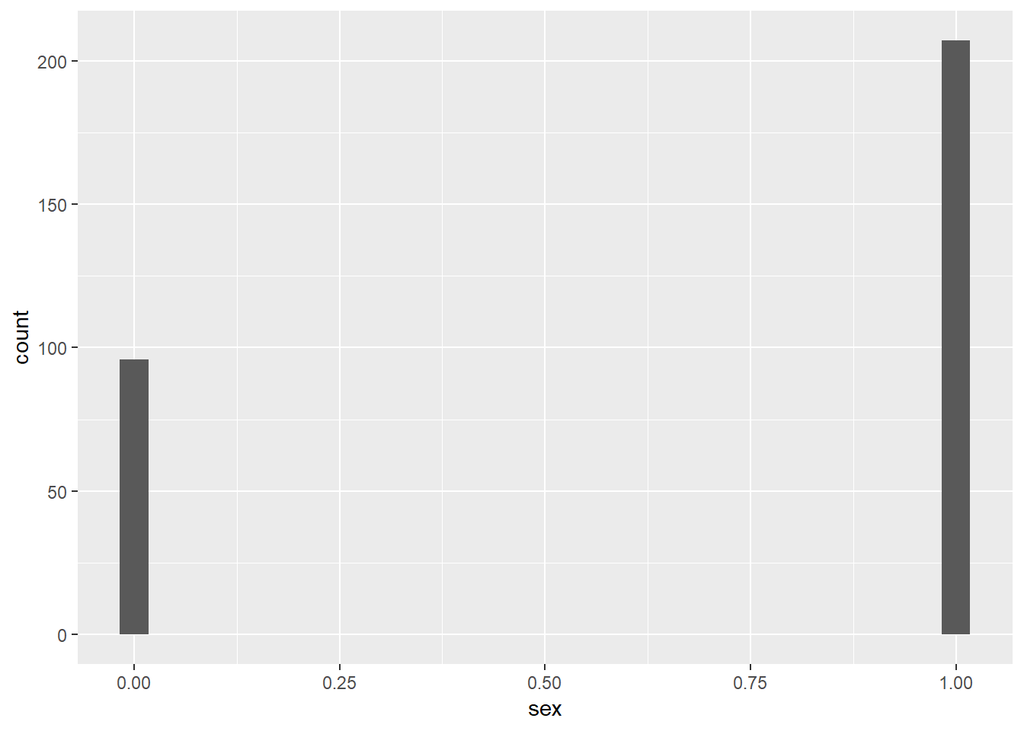

```r
library(ggplot2)
data %>%
  ggplot(aes(x=sex)) +
    geom_histogram()
```

Note that in this particular dataset, sex is represented as a number, male=1, female = 0, and so a histogram can still be used to represent the dataset.

**Histogram of cholesterol**

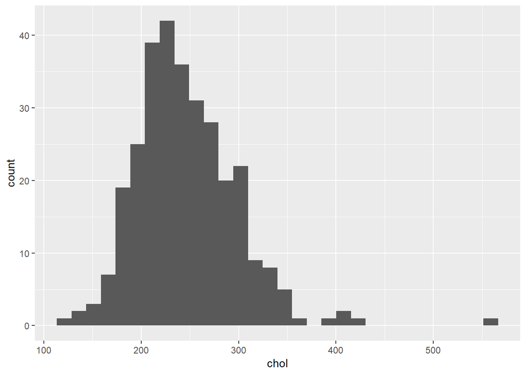

```r
data %>%
  ggplot(aes(x=chol)) +
    geom_histogram()
```

The graph of cholesterol appears to follow a normal distribution (unimodal around 225, symmetric, evenly spread)

**Resting blood pressure**

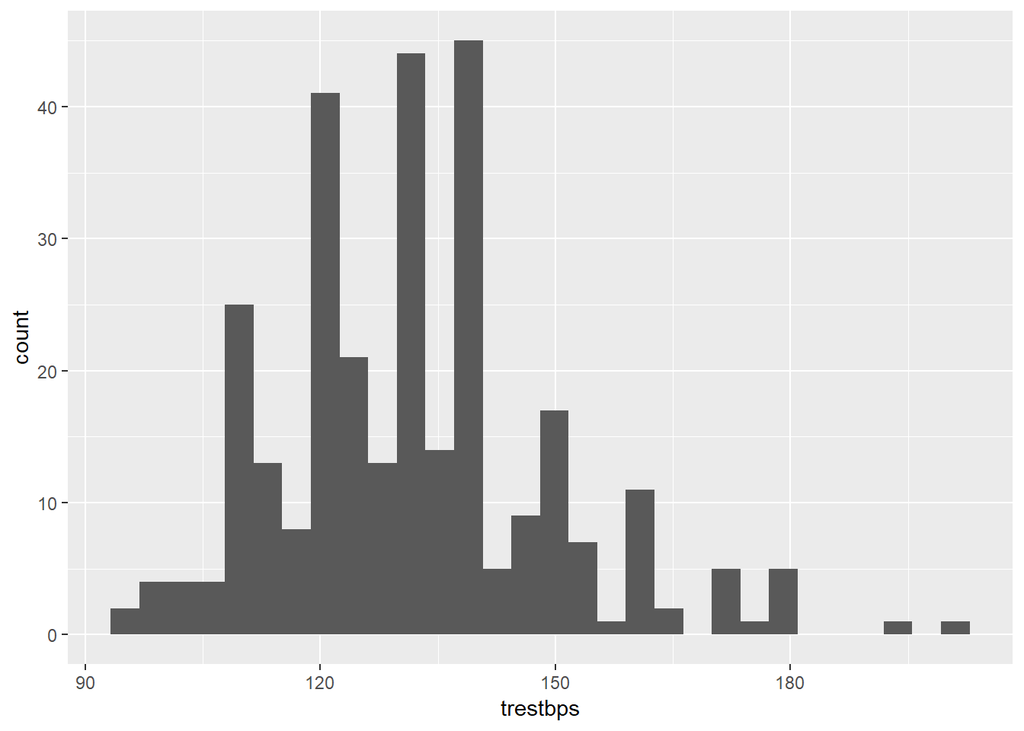

```r
data %>%
  ggplot(aes(x=trestbps)) +
    geom_histogram()
```

The graph of resting blood pressure is also somewhat symmetric, although there are a few outliers that are higher than 180.

**Chest pain type**

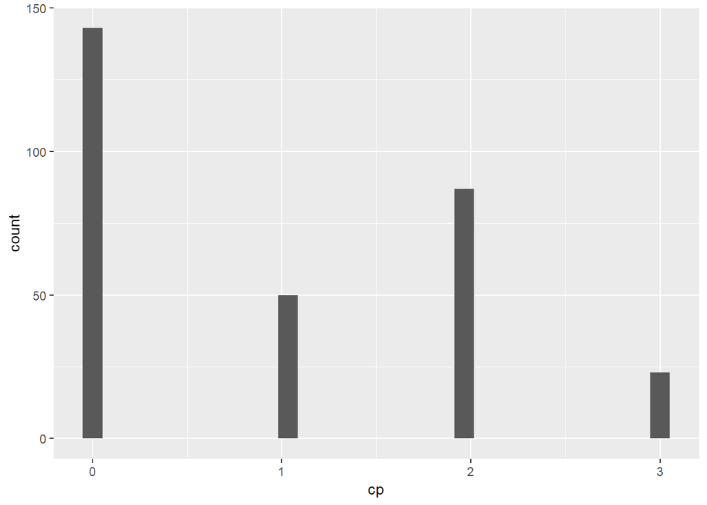

```r
data %>%
  ggplot(aes(x=cp)) +
    geom_histogram()
```

A simple graph of the distribution of patients with the different types of chest pain.

**Histogram of age:**

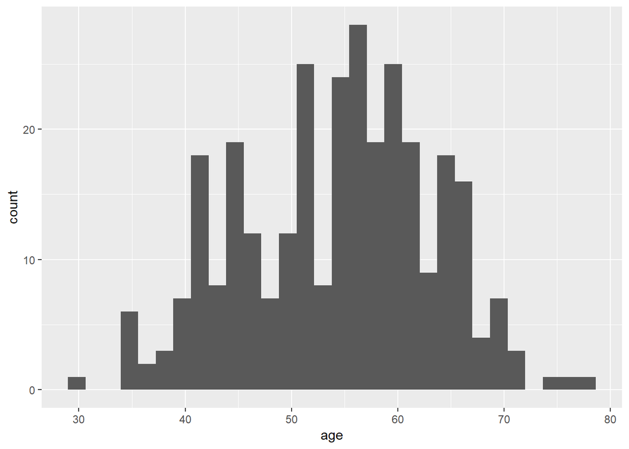

```r
data %>%
  ggplot(aes(x=age)) +
    geom_histogram()
```

Looking at age, it appears as though the ages range from around 30 to 80, and appear to follow a normal distribution (unimodal, symmetric, evenly spread). Note that age (in this format) is a discrete numeric variable.

We do a similar histogram for the spread of age, but only for those individuals who have heart disease.

**histogram of distribution of age for people with heart disease* in the sample:**

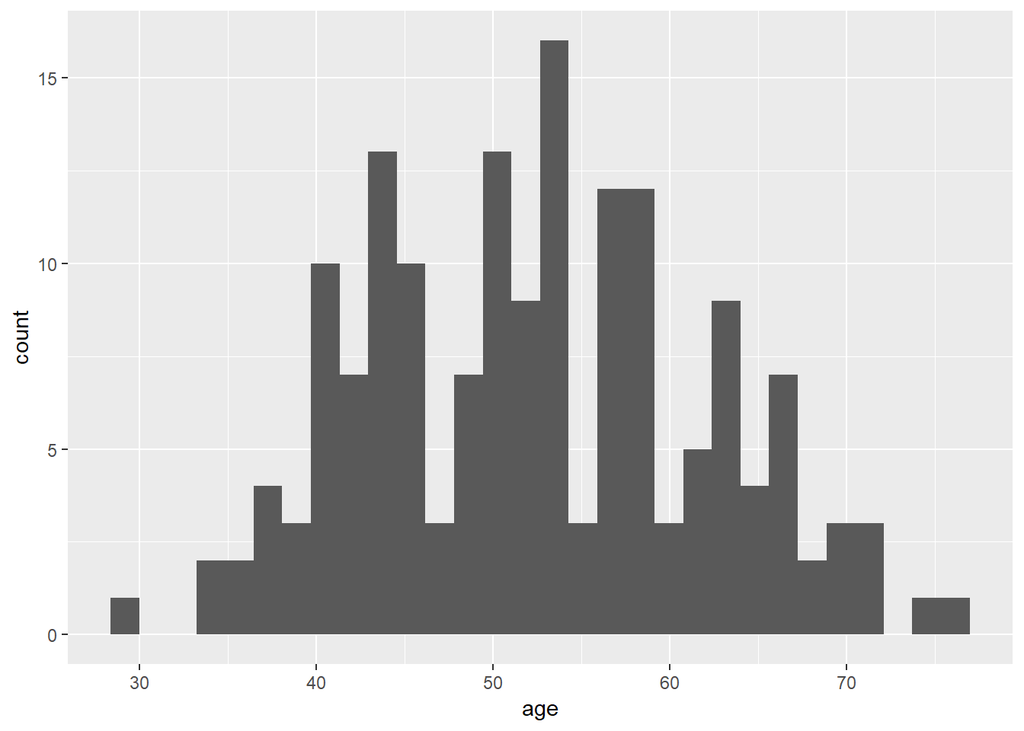

```r
data %>%
  filter(target==1) %>%
  ggplot(aes(x=age)) +
  geom_histogram()
```

Judging from the dataset above, we can see that the age distribution of people with heart disease also follows a normal distribution. This is important if we want to conduct hypothesis testing on it.

Let’s now perform aggregation on the attribute **age**. To use aggregate functions and grouping, we need to first convert **age** into a categorical variable. For more information about the differences between categorical and numeric (discrete vs continous), you can check this link:

https://support.minitab.com/en-us/minitab-express/1/help-and-how-to/modeling-statistics/regression/supporting-topics/basics/what-are-categorical-discrete-and-continuous-variables/

**Creating a new attribute:**

```r
data_categorical <- data %>%
  mutate(age_categorical = cut(age, breaks = 8))
```

We have now created a new dataset with a new attribute called **age_categorical** (the age of patients split into 8 groups using **cut** and **break**). We now can use this to perform grouping and summarization, which is an important step in EDA.

**For more information on the summarize function:**

https://www.r-bloggers.com/how-to-summarize-a-data-frame-by-groups-in-r/

**Summarizing data and making a graph and bar plot of age vs percentage of patients with heart disease.**

```r
data_categorical %>%
  select(age_categorical, target) %>%
  group_by(age_categorical) %>%
  summarize(Heart_Disease = sum(target), total = n(), Percent_Hd_In_Category = Heart_Disease/total *100)
```

```
## # A tibble: 8 x 4
##   age_categorical Heart_Disease total Percent_Hd_In_Category
##   <fct>                   <int> <int>                  <dbl>
## 1 (29,35]                     5     7                   71.4
## 2 (35,41]                    17    22                   77.3
## 3 (41,47]                    33    47                   70.2
## 4 (47,53]                    35    52                   67.3
## 5 (53,59]                    37    85                   43.5
## 6 (59,65]                    21    57                   36.8
## 7 (65,71]                    15    30                   50
## 8 (71,77]                     2     3                   66.7
```

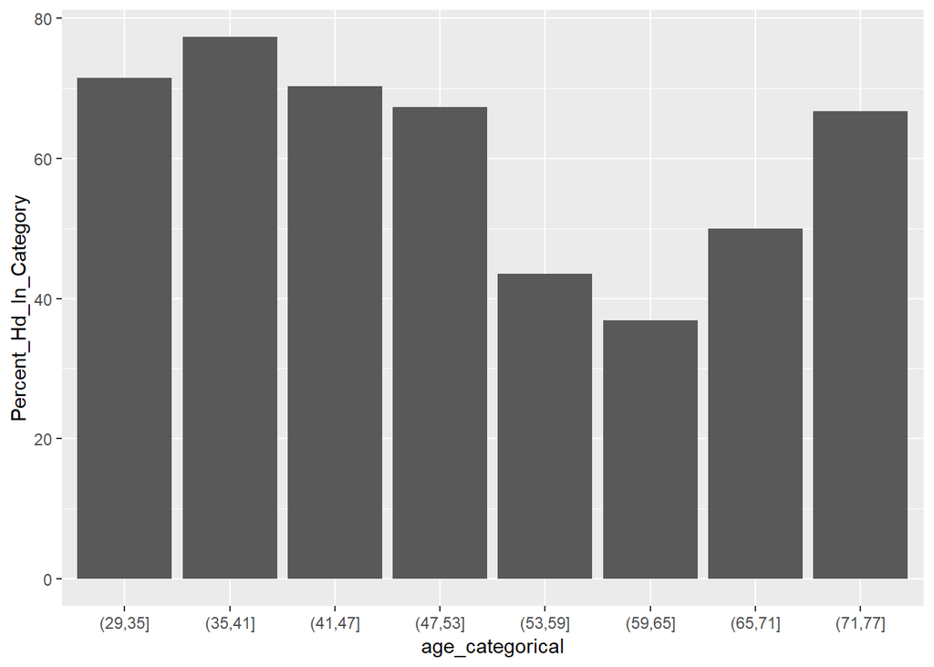

```r
data_categorical %>%
  select(age_categorical, target) %>%
  group_by(age_categorical) %>%
  summarize(Heart_Disease = sum(target), total = n(), Percent_Hd_In_Category = Heart_Disease/total *100) %>%
  ggplot(aes(x=age_categorical, y=Percent_Hd_In_Category)) +
  geom_bar(stat = "identity")
```

From a glance, judging by age alone, there does not appear to be a linear relationship between heart disease and age, but there appears to be some form of relationship between the two factors, particularily the age group (59-65), which has a lower proportion of patients with chest pain that are diagnosed with heart disease. This is somewhat interesting, and we will go back to this variable in the hypothesis testing step.

**We can do a similar chart, using high fasting blood sugar (diabetes) vs heart disease. (Using a scatter plot (geom_point) instead of a bar graph)**

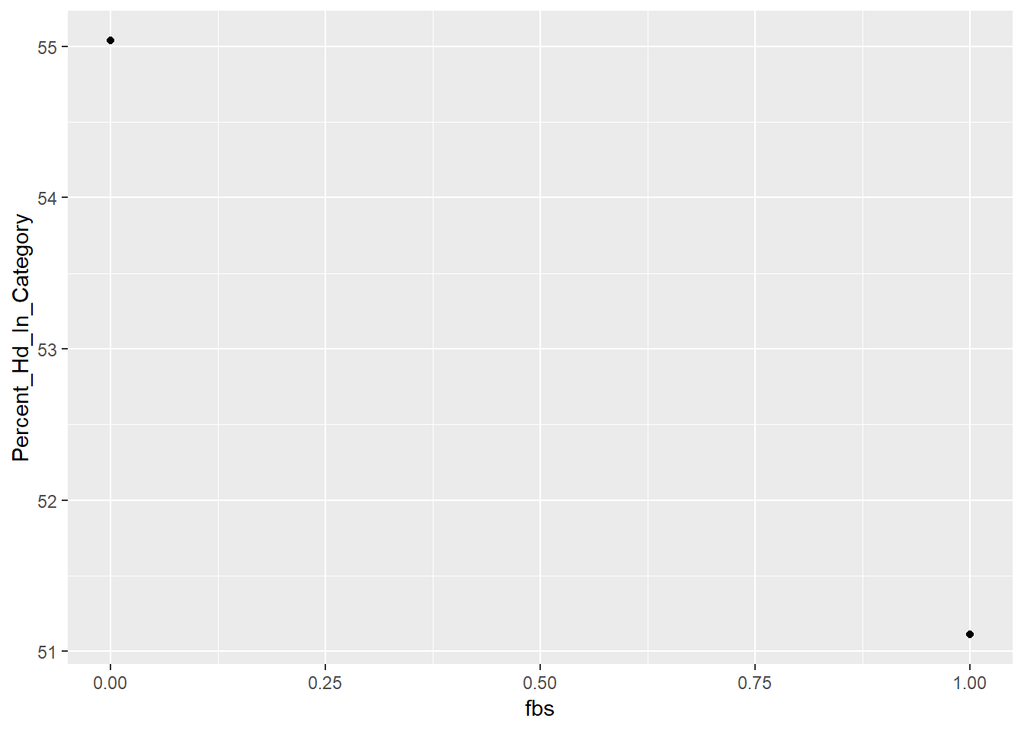

```r
data_categorical %>%
  select(fbs, target) %>%
  group_by(fbs) %>%
  summarize(Heart_Disease = sum(target), total = n(), Percent_Hd_In_Category = Heart_Disease/total *100) %>%
  ggplot(aes(x=fbs, y=Percent_Hd_In_Category)) +
  geom_point()
```

About 55% of patients with fasting blood sugar <= 120 had heart disease, and about 51% of patients with fasting blood sugar > 120 had heart disease.

**The person’s maximum heart rate achieved:**

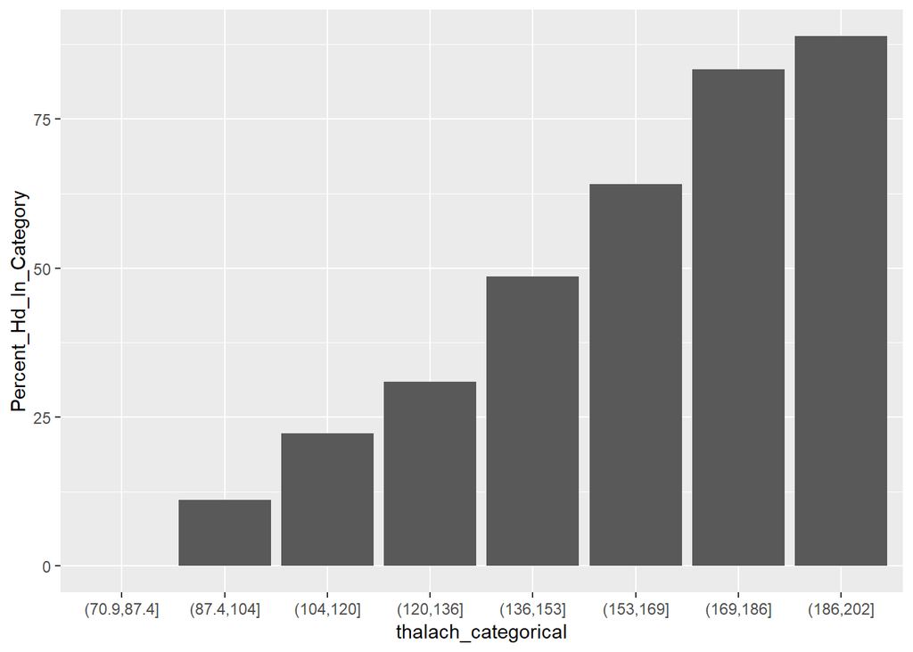

```r
data_categorical <- data_categorical %>%
  mutate(thalach_categorical = cut(thalach, breaks = 8))
data_categorical %>%
  select(thalach_categorical, target) %>%
  group_by(thalach_categorical) %>%
  summarize(Heart_Disease = sum(target), total = n(), Percent_Hd_In_Category = Heart_Disease/total *100) %>%
  ggplot(aes(x=thalach_categorical, y=Percent_Hd_In_Category)) +
  geom_bar(stat = "identity")
```

This categorical variable appears to form some relationship with proportion of heart disease diagnosis, with higher maximum heart rate groups correlating to higher proportion of heart disease in the population. While it does not make sense use linear regression on thalach vs proportion (because it is a categorical variable), we can still use random forest classifiers draw a conclusion from our dataset.

**Histogram of oldpeak: ST depression induced by exercise relative to rest:** (‘ST’ relates to positions on the ECG plot. More information is provided below)

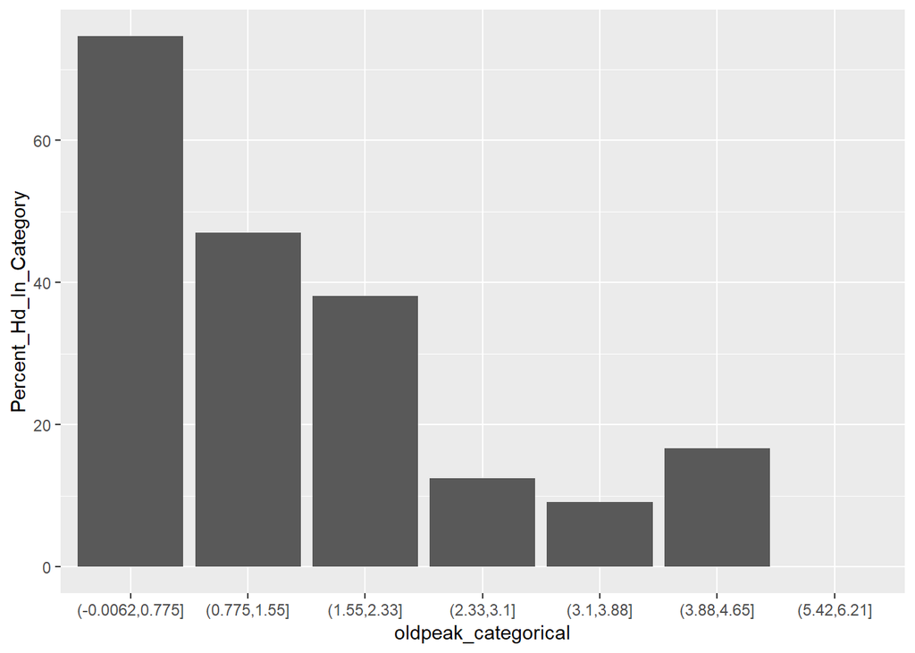

```r
data_categorical <- data_categorical %>%
  mutate(oldpeak_categorical = cut(oldpeak, breaks = 8))
data_categorical %>%
  select(oldpeak_categorical, target) %>%
  group_by(oldpeak_categorical) %>%
  summarize(Heart_Disease = sum(target), total = n(), Percent_Hd_In_Category = Heart_Disease/total *100) %>%
  ggplot(aes(x=oldpeak_categorical, y=Percent_Hd_In_Category)) +
  geom_bar(stat = "identity")
```

This variable also appears to have some form of relationship with the proportion of heart disease diagnosis. The groups with higher **oldpeak** values appear to have lower proportions of heart disease diagnosis.

# **Hypothesis Testing**

One of the ways we can draw conclusions from data is by using hypothesis testing. For instance, suppose we wanted to go back to one of the risk factors, **age**, and draw some conclusion on that variable.

Recall that in the age histogram, the age group 59-65 had the lowest proportion of heart disease diagnosis. One of the things that we can do in R, is to conduct A-B hypothesis testing on the proportions of age groups diagnosed with heart disease to see whether this lowest proportion is **statistically significant**.

For more information on hypothesis testing: https://stattrek.com/hypothesis-test/difference-in-proportions.aspx

Our age hypothesis test:

We will let **A** represent the group of aged 59-65 patients and **B** represent the group of aged 29-77 patients (the entire dataset)

**Null hypothesis:** The proportion of patients, aged 59-65 and diagnosed with heart disease, is the same as the proportion of patients aged 29-77. (Note that if ages 29-77, excluding 59-65, has the same proportion as 59-65 then the proportion is the same as 29-77)

p(59<=age<=65) >= p(29<=age<=77) . In other words that A=B

**Alternative Hypothesis:** The proportion of patients, aged 59-65 and diagnosed with heart disease, is lower than the proportion of patients aged 29-77, excluding ages 59-65.

p(59<=age<=65) < p(29<=age<=77) . In other words, that A-B is less than 0, or that B-A is greater than 0. (Both mean the same thing, and tests can be conducted both ways on A-B < 0 or B-A > 0)

## **Setting up the hypothesis test:**

**Recall this graph of proportions:**

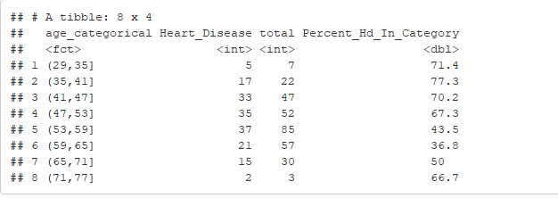

Under the assumption that the proportion of diagnosis of heart disease for the patients follows a normal distribution, we conduct a proportion test of difference.

We let Sx represent the number of heart disease patients in a particular group x, Nx represent the number of patients belonging in group x, and Px represent the probability a patient that belongs in group x has heart disease.

```r
Pa <- 21/57
Na <- 57
Sa <- 21

data_categorical <- data_categorical %>%
  select(age_categorical, target) %>%
  summarize(hd_count = sum(target), total_count = n())
```

We separate the group (age 59-65) from the dataset that contains the entire age range.

```r
Sb <- (data_categorical$hd_count) - Sa
Nb <- (data_categorical$total_count) - Na
Pb <- Sb/Nb

Sb
```

```
## [1] 144
```

```r
Nb
```

```
## [1] 246
```

```r
Pb
```

```
## [1] 0.5853659
```

Now we have (Sa, Na, Pa) and (Sb, Nb, Pb) which represent data for the groups A (ages 59-65) and B (Ages not in A) respectively.

With these numbers we can compute variance, and conduct our two proportion hypothesis test. We estimate our pooled proportion p as (Sa + Sb) / (Na + Nb). We then use this pooled proportion to calculate the pooled variance. Finally, we compute the difference in proportions, which we will denote as Y_hat. We do the test on B > A, which is the same as conducting the test on A < B, and so we can just use Y_hat = Pb - Pa.

```r
p <- (Sa + Sb) / (Na + Nb)
pooled_Variance <- p*(1-p) * (1/Nb + 1/Na)
Y_hat <- Pb - Pa

p
```

```
## [1] 0.5445545
```

```r
pooled_Variance
```

```
## [1] 0.005359329
```

```r
Y_hat
```

```
## [1] 0.2169448
```

With these 3 numbers, we can use the pnorm function to compute the hypothesis test. The three arguments are the sample difference proportion mean, the value of the mean under the null hypothesis, and the standard deviation, computed by the square root of the pooled variance. Note that pnorm finds the proportion of all the values below the mean, so in this case, pnorm finds the proportion of all values that are below B-A. (or above A-B). The diagram below provides a graphical representation of the area that pnorm calculates:

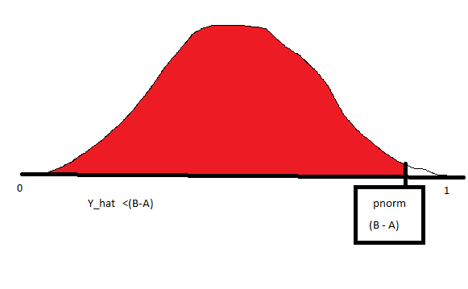

To find the probability that we obtained a difference greater than Y_hat, we do 1-pnorm.

```r
1-pnorm(Y_hat, mean = 0, sd = sqrt(pooled_Variance))
```

```
## [1] 0.001521178
```

At a significance level of 0.05, the value 0.00152 is statistically significant, since the chance of obtaining this sample is significantly lower than the 0.05 probability setting. Therefore, we reject the null hypothesis in favor of the alternative hypothesis (Patients within the age group 59-65 admitted to the clinic due to chest pain have a lower proportion of heart disease)

# **Random Forest**

We move on to the final step of the tutorial: Random Forest.

First, we insert the appropriate packages for randomForest:

```r
library(caret)
library(randomForest)
```

We specify our target variable **target_str** as our categorical factor. We use the table function to show the number of patients who have/don’t have heart disease. (Yes = has heart disease, No = does not have heart disease).

(Information on factors in R:) https://www.stat.berkeley.edu/~s133/factors.html

```r
rf_data$target_str <- as.factor(rf_data$target_str)
table(rf_data$target_str)
```

```
##
##  No Yes
## 138 165
```

The next step involves the use of the random number generator. While the computer typically generates random results, we want our results to be reproducible (see for information about seeds: https://stat.ethz.ch/pipermail/r-help/2013-December/363944.html)

We use the set.seed(x) function for this purpose. We then use the sample function to randomly sample data from our dataset **rf_data** into our two different groups (training set and test set). The probability values that we selected (0.7 and 0.3) are arbitrarily chosen, but in general you want to have a higher proportion of data belonging to the training set, unless you have a large amount of data available.

Once we have our training set, we can train our random forest classifier, which we name **rf**. This is done by inputting the feature we want to predict **target_str**, and the training set to the randomForest() function.

```r
set.seed(1234)
ind <- sample(2, nrow(rf_data), replace = TRUE, prob = c(0.7,0.3))
train <- rf_data[ind==1,]
test <- rf_data[ind==2,]

rf <- randomForest(target_str~., data=train)

print(rf)
```

```
##
## Call:
##  randomForest(formula = target_str ~ ., data = train)
##                Type of random forest: classification
##                      Number of trees: 500
## No. of variables tried at each split: 4
##
##         OOB estimate of  error rate: 23.29%
## Confusion matrix:
##     No Yes class.error
## No  69  26   0.2736842
## Yes 25  99   0.2016129
```

```r
attributes(rf)
```

```
## $names
##  [1] "call"            "type"            "predicted"
##  [4] "err.rate"        "confusion"       "votes"
##  [7] "oob.times"       "classes"         "importance"
## [10] "importanceSD"    "localImportance" "proximity"
## [13] "ntree"           "mtry"            "forest"
## [16] "y"               "test"            "inbag"
## [19] "terms"
##
## $class
## [1] "randomForest.formula" "randomForest"
```

The next few lines of code show some of the results obtained from performing Random Forest on the dataset. Note that confusion refers to the confusion matrix (information about true positives, false negatives, etc … how well the data is classified), and mtry refers to the number of variables available for splitting at each tree’s top node. You can refer to this link for more information about these terms:

https://www.rdocumentation.org/packages/randomForest/versions/4.6-14/topics/randomForest

For information about confusion matrices:

https://www.dataschool.io/simple-guide-to-confusion-matrix-terminology/

```r
rf$confusion
```

```
##     No Yes class.error
## No  69  26   0.2736842
## Yes 25  99   0.2016129
```

```r
rf$mtry
```

```
## [1] 4
```

Now that we trained our random forest classifier, how accurately can we predict the test set? We use the predict function to find out, inputting our **rf** model and **test** dataset. The table below shows 84 entries.

```r
p2 <- predict(rf, test)
p2
```

```
##   5  14  16  26  28  29  36  39  40  50  53  58  60  61  66  72  74  81
## Yes Yes Yes Yes Yes Yes Yes Yes Yes Yes  No  No  No Yes Yes Yes Yes Yes
##  86  90  92 100 111 113 116 117 120 121 122 123 124 131 135 137 140 142
##  No  No  No Yes  No Yes Yes Yes Yes  No  No Yes Yes Yes Yes Yes  No  No
## 147 149 154 156 158 169 171 173 176 185 187 190 192 194 195 196 197 198
## Yes Yes Yes  No Yes  No Yes Yes  No  No  No Yes  No  No Yes  No Yes  No
## 199 204 206 210 214 216 218 220 227 231 234 237 240 245 247 249 250 261
##  No  No Yes  No  No  No  No  No  No Yes  No  No  No  No  No Yes  No  No
## 267 270 272 274 277 283 284 285 290 293 296 302
##  No  No Yes Yes  No Yes Yes  No  No  No  No  No
## Levels: No Yes
```

```r
confusionMatrix(p2, test$target_str)
```

```
## Confusion Matrix and Statistics
##
##           Reference
## Prediction No Yes
##        No  31  12
##        Yes 12  29
##
##                Accuracy : 0.7143
##                  95% CI : (0.6053, 0.8076)
##     No Information Rate : 0.5119
##     P-Value [Acc > NIR] : 0.0001269
##
##                   Kappa : 0.4282
##
##  Mcnemar's Test P-Value : 1.0000000
##
##             Sensitivity : 0.7209
##             Specificity : 0.7073
##          Pos Pred Value : 0.7209
##          Neg Pred Value : 0.7073
##              Prevalence : 0.5119
##          Detection Rate : 0.3690
##    Detection Prevalence : 0.5119
##       Balanced Accuracy : 0.7141
##
##        'Positive' Class : No
##
```

From the confusion matrix, we can see that our true-negative count (correctly predicted No’s) is 31, true-positive count (correctly predicted Yes’s is 29). Our false-negative and false-positive count is 12. Out of the 84 test entries, 60 were correctly predicted, which is, as shown, an accuracy of 0.7143.

Finally, we look at which features have the highest impact on classification: Note that **MeanDecreaseGini** refers to the **Gini Impurity** or **Information Gain** (see for more details on how it is computed: https://en.wikipedia.org/wiki/Decision_tree_learning)

Overall, a higher Mean Decrease of Gini when a feature is removed, indicates that the feature has a higher impact on classification.

```r
importance(rf)
```

```
##                              MeanDecreaseGini
## age                                9.67756529
## trestbps                           7.62762702
## chol                              10.00937929
## thalach                           13.36208644
## oldpeak                           10.91014169
## male                               1.58098657
## female                             1.58664348
## cp_typical_angina                 14.34546411
## cp_atypical_angina                 2.02183199
## cp_non_anginal_pain                2.62668661
## cp_asymptomatic                    1.71512143
## restecg_normal                     1.74355585
## restecg_stt_wave                   1.76916148
## restecg_probable_ventricular       0.08718987
## slope_upsloping                    0.73189796
## slope_flat                         4.02090691
## slope_downsloping                  4.68008026
## thal_none                          0.15736756
## thal_normal                        0.64789124
## thal_fixed_defect                  6.58042008
## thal_reversable_defect             6.08955583
```

We can then plot the feature importance for easy visualization:

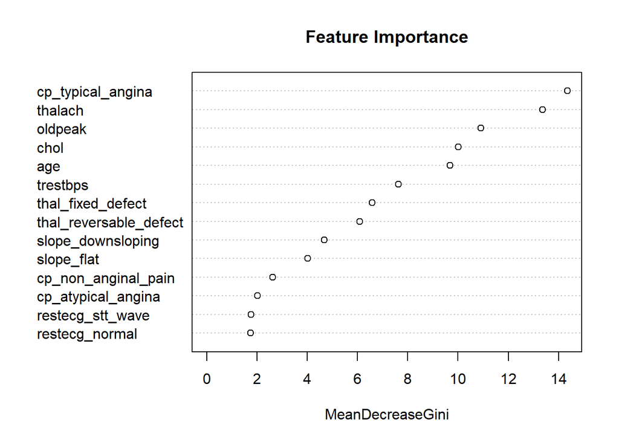

```r
varImpPlot(rf,sort=T, n.var= 14, main = "Feature Importance")
```

Useful youtube guide for random forest:

https://www.youtube.com/watch?v=dJclNIN-TPo

# **Conclusion:**

In conclusion, by using random forest, we have found the attributes which are correlated the most with a heart disease diagnosis, and we were even able to sort these attributes in order of which feature has the highest prediction rate.

From the confusion matrix, we saw that we were able to obtain an prediction accuracy of about 71% from our model, which is a decent level of accuracy given how hard it can be to predict someone’s health just from their attributes alone.

Finally, while the results of this experiment (like which attributes are correlated with heart disease) in this tutorial are not surprising and agree with common medical knowledge (and experiments like this have already been done in the past—we all know how certain risk factors affect heart disease due to these past studies), the model we created can potentially have some use, if we were to, for example, try to predict without needing a doctor whether a patient has heart disease or not.